# Reproductive Efficiency Sensitivity Analysis in ZooMSS

Uniform and Group-Specific repro_eff Across an Effort Gradient

ZooMSS Development

2026-02-23

```r
library(here)
devtools::load_all(here())
library(ggplot2)
library(patchwork)
library(dplyr)
```

# 1 Introduction

The yield–effort curve should display the classic dome shape: catch increases with effort to a maximum (MSY), then declines as the stock collapses under overfishing. If the curve is monotonically increasing (or only weakly declining), fish groups are replacing biomass too quickly — the stock–recruitment link is too efficient.

The reproductive efficiency parameter `repro_eff` controls the fraction of reproductive output (eggs/larvae) that survive to become recruits at the smallest fish size class. It is the primary lever determining how resilient fish populations are to fishing mortality.

Throughout, catchability is held constant at `q = 1` so that `F = effort × selectivity` directly, and the effort gradient ranges from 0 to 5.

## 1.1 Prerequisites

Model runs are computationally expensive. This document **loads pre-computed results** from `.rds` files generated by the companion script `run_repro_eff_sweep.R`. Run that script first:

```
Rscript run_repro_eff_sweep.R
```

Results are saved to the `repro_eff_cache/` directory. If the cache files are not found, this document will stop with an informative error.

# 2 Load Cached Results

```r
cache_dir <- "repro_eff_cache"

# Validate cache exists
required_files <- c("results_uniform_repro.rds",
                    "results_group_repro.rds",
                    "sweep_config.rds")
missing <- required_files[!file.exists(file.path(cache_dir, required_files))]

if (length(missing) > 0) {
  stop("Missing cached results in '", cache_dir, "/':\n  ",
       paste(missing, collapse = "\n  "),
       "\n\nRun 'Rscript run_repro_eff_sweep.R' first to generate them.")
}

# Load
sweep_config        <- readRDS(file.path(cache_dir, "sweep_config.rds"))
results_repro       <- readRDS(file.path(cache_dir, "results_uniform_repro.rds"))
results_group_repro <- readRDS(file.path(cache_dir, "results_group_repro.rds"))

cat("Loaded cached results generated on:", format(sweep_config$timestamp), "\n")
```

```
#> Loaded cached results generated on: 2026-02-23 14:44:08
```

```r
cat("R version used for sweep:", sweep_config$r_version, "\n")
```

```
#> R version used for sweep: R version 4.5.1 (2025-06-13 ucrt)
```

```r
cat("Cores used:", sweep_config$n_cores_used, "\n")
```

```
#> Cores used: 15
```

```r
# Check if Part 2 data is available (allows rendering with Part 1 only)
has_part2 <- length(results_group_repro) > 0 &&
             length(results_group_repro[[1]]) > 0
if (!has_part2) cat("\nNote: Part 2 results not yet available — those sections will be skipped.\n")
```

```r
# Unpack configuration so downstream chunks can reference them directly
effort_levels    <- sweep_config$effort_levels
repro_eff_values <- sweep_config$repro_eff_values
repro_scenarios  <- sweep_config$repro_scenarios
scenario_names   <- sweep_config$scenario_names
q_fixed          <- sweep_config$q_fixed
fish_names       <- sweep_config$fish_names
num_fish         <- length(fish_names)
```

# 3 Helper Functions

```r
# Get consistent fish colours from a model object
get_fish_colours <- function(mdl) {
  fc <- mdl$param$Groups$PlotColour[mdl$param$fish_grps]
  names(fc) <- mdl$param$Groups$Species[mdl$param$fish_grps]
  fc
}

# Get all group colours
get_all_colours <- function(mdl) {
  ac <- mdl$param$Groups$PlotColour
  names(ac) <- mdl$param$Groups$Species
  ac
}

# Extract equilibrium metrics for one model run and one fish group
extract_equilibrium <- function(mdl_i, f, fish_grps) {
  nsave     <- length(mdl_i$time)
  final_idx <- max(1, floor(nsave * 0.5)):nsave
  fg        <- fish_grps[f]

  eq_bm <- mean(apply(
    mdl_i$abundance[final_idx, fg, , drop = FALSE], 1, function(row) {
      sum(row * mdl_i$param$w * mdl_i$param$dx)
    }))

  eq_catch <- if (!is.null(mdl_i$catch)) {
    mean(mdl_i$catch[final_idx, f], na.rm = TRUE)
  } else { 0 }

  eq_ssb <- mean(mdl_i$SSB[final_idx, f], na.rm = TRUE)
  eq_rec <- mean(mdl_i$recruitment[final_idx, f], na.rm = TRUE)

  data.frame(eq_catch = eq_catch, eq_biomass = eq_bm,
             eq_SSB = eq_ssb, eq_recruitment = eq_rec)
}
```

# 4 Part 1: Uniform Reproductive Efficiency

## 4.1 Extract Equilibrium Summary

Averaged over the final 200 years of each 400-year run (years 200–400) to approximate long-term steady state.

```r
repro_summary <- data.frame()

for (re_idx in seq_along(repro_eff_values)) {
  for (eff_idx in seq_along(effort_levels)) {

    mdl_i     <- results_repro[[re_idx]][[eff_idx]]
    fish_grps <- mdl_i$param$fish_grps

    for (f in seq_len(num_fish)) {
      eq <- extract_equilibrium(mdl_i, f, fish_grps)
      repro_summary <- rbind(repro_summary, cbind(
        data.frame(repro_eff  = repro_eff_values[re_idx],
                   effort     = effort_levels[eff_idx],
                   fish_group = fish_names[f]),
        eq
      ))
    }
  }
}

repro_summary$repro_eff_label <- paste0(
  "repro_eff = ", format(repro_summary$repro_eff, scientific = TRUE))
```

## 4.2 Yield–Effort Curves

The key diagnostic: for each `repro_eff` value, does the yield–effort curve show a dome?

### 4.2.1 Absolute Yield

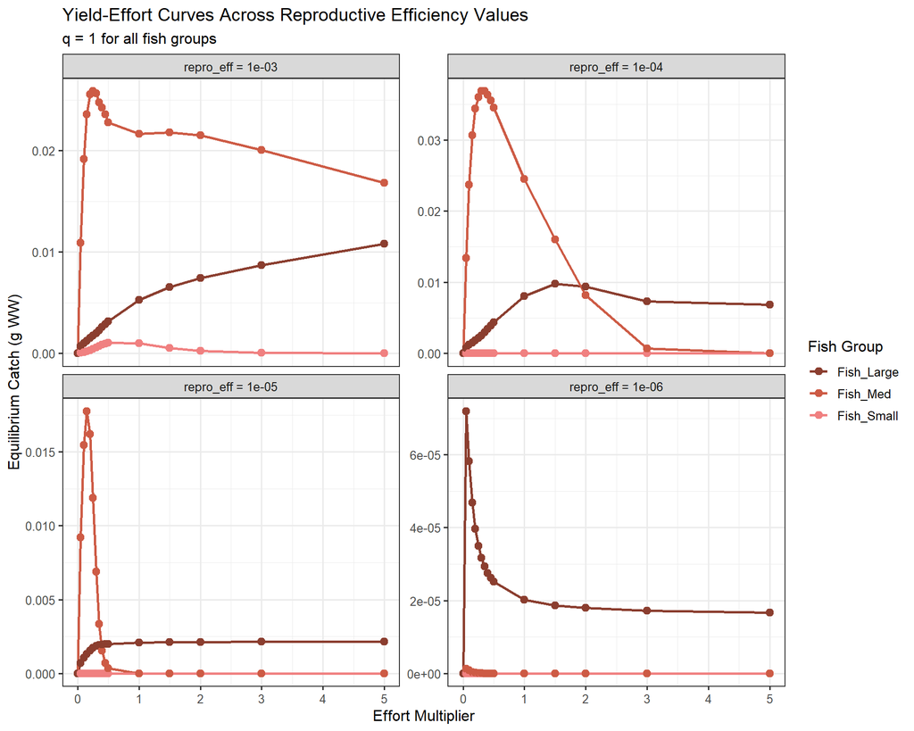

```r
fish_colours <- get_fish_colours(results_repro[[1]][[1]])

ggplot(repro_summary,
       aes(x = effort, y = eq_catch, colour = fish_group)) +
  geom_line(linewidth = 1.0) +
  geom_point(size = 2.5) +
  facet_wrap(~ repro_eff_label, scales = "free_y", ncol = 2) +
  scale_colour_manual(values = fish_colours) +
  theme_bw(base_size = 12) +
  labs(x      = "Effort Multiplier",
       y      = "Equilibrium Catch (g WW)",
       colour = "Fish Group",
       title  = "Yield-Effort Curves Across Reproductive Efficiency Values",
       subtitle = paste0("q = ", q_fixed, " for all fish groups"))
```

### 4.2.2 Normalised Yield

Normalising each group’s yield to its own maximum makes the dome shape (or absence thereof) easier to compare.

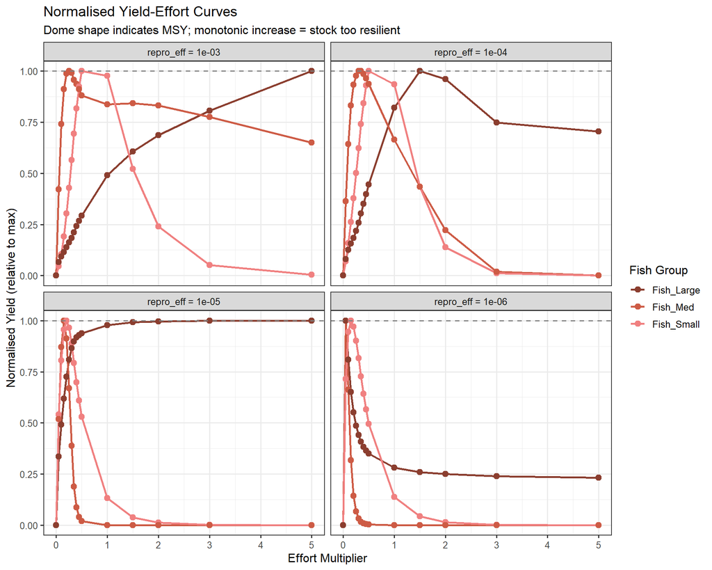

```r
repro_summary <- repro_summary %>%
  group_by(repro_eff_label, fish_group) %>%
  mutate(yield_norm = eq_catch / max(eq_catch, na.rm = TRUE)) %>%
  ungroup()

ggplot(repro_summary,
       aes(x = effort, y = yield_norm, colour = fish_group)) +
  geom_line(linewidth = 1.0) +
  geom_point(size = 2.5) +
  geom_hline(yintercept = 1, linetype = "dashed", colour = "grey50") +
  facet_wrap(~ repro_eff_label, ncol = 2) +
  scale_colour_manual(values = fish_colours) +
  theme_bw(base_size = 12) +
  labs(x      = "Effort Multiplier",
       y      = "Normalised Yield (relative to max)",
       colour = "Fish Group",
       title  = "Normalised Yield-Effort Curves",
       subtitle = "Dome shape indicates MSY; monotonic increase = stock too resilient")
```

## 4.3 Biomass Depletion

Lower `repro_eff` should make stocks more vulnerable — biomass should decline more steeply with effort.

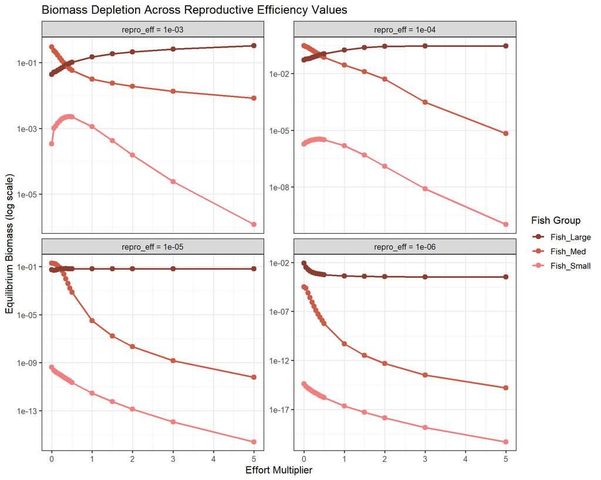

```r
ggplot(repro_summary,
       aes(x = effort, y = eq_biomass, colour = fish_group)) +
  geom_line(linewidth = 1.0) +
  geom_point(size = 2.5) +
  facet_wrap(~ repro_eff_label, scales = "free_y", ncol = 2) +
  scale_colour_manual(values = fish_colours) +
  scale_y_log10() +
  theme_bw(base_size = 12) +
  labs(x      = "Effort Multiplier",
       y      = "Equilibrium Biomass (log scale)",
       colour = "Fish Group",
       title  = "Biomass Depletion Across Reproductive Efficiency Values")
```

## 4.4 SSB and Recruitment

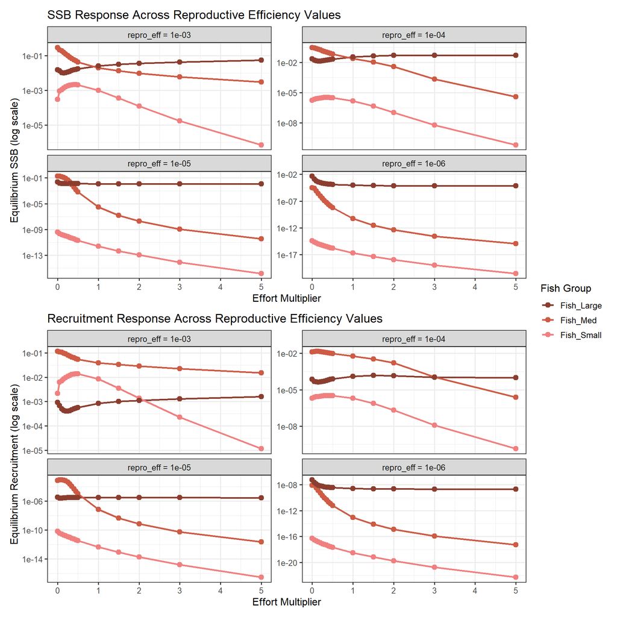

```r
p_ssb_re <- ggplot(repro_summary,
                   aes(x = effort, y = eq_SSB, colour = fish_group)) +
  geom_line(linewidth = 1.0) +
  geom_point(size = 2.5) +
  facet_wrap(~ repro_eff_label, scales = "free_y", ncol = 2) +
  scale_colour_manual(values = fish_colours) +
  scale_y_log10() +
  theme_bw(base_size = 12) +
  labs(x      = "Effort Multiplier",
       y      = "Equilibrium SSB (log scale)",
       colour = "Fish Group",
       title  = "SSB Response Across Reproductive Efficiency Values")

p_rec_re <- ggplot(repro_summary,
                   aes(x = effort, y = eq_recruitment, colour = fish_group)) +
  geom_line(linewidth = 1.0) +
  geom_point(size = 2.5) +
  facet_wrap(~ repro_eff_label, scales = "free_y", ncol = 2) +
  scale_colour_manual(values = fish_colours) +
  scale_y_log10() +
  theme_bw(base_size = 12) +
  labs(x      = "Effort Multiplier",
       y      = "Equilibrium Recruitment (log scale)",
       colour = "Fish Group",
       title  = "Recruitment Response Across Reproductive Efficiency Values")

wrap_plots(p_ssb_re, p_rec_re, ncol = 1, guides = "collect")
```

## 4.5 Combined Overlay

A single-panel comparison per fish group to directly see the effect of reducing reproductive efficiency.

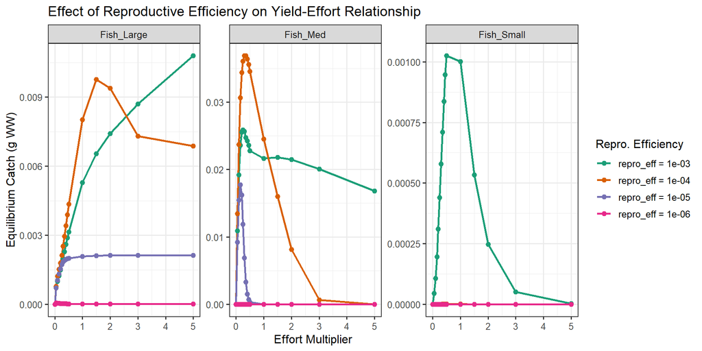

```r
ggplot(repro_summary,
       aes(x = effort, y = eq_catch,
           colour = repro_eff_label, group = repro_eff_label)) +
  geom_line(linewidth = 0.9) +
  geom_point(size = 2) +
  facet_wrap(~ fish_group, scales = "free_y") +
  theme_bw(base_size = 12) +
  scale_colour_brewer(palette = "Dark2") +
  labs(x      = "Effort Multiplier",
       y      = "Equilibrium Catch (g WW)",
       colour = "Repro. Efficiency",
       title  = "Effect of Reproductive Efficiency on Yield-Effort Relationship")
```

## 4.6 Interpretation

If the dome shape only emerges at lower `repro_eff` values:

- The current default (`repro_eff = 0.001`) is too high — stocks can replace harvested biomass faster than fishing removes it, preventing the overexploitation phase of the yield curve.
- The appropriate `repro_eff` should produce a dome where MSY occurs at a realistic effort level (roughly `effort = 1–2` depending on the group).

If none of the tested values produce a dome, the resilience may be coming from elsewhere in the model (e.g. density-dependent growth, the stock–recruitment functional form, or the interaction between fish groups via shared prey).

# 5 Part 2: Group-Specific Reproductive Efficiency

Part 1 applied the same `repro_eff` to all three fish groups. In practice, reproductive efficiency should differ by life history: small, fast-turnover fish (r-strategists) typically have higher egg-to-recruit survival than large, slow-growing fish (K-strategists) because small fish mature earlier, produce more frequent cohorts, and face lower cumulative larval mortality relative to their adult population turnover.

Here we test a set of **group-specific `repro_eff` combinations** across the same effort gradient to identify whether differential reproductive efficiency produces more realistic yield curves — in particular, whether large fish collapse at lower effort while small fish remain productive.

### 5.0.1 Scenario Definitions

```r
# Display scenario table
scenario_df <- do.call(rbind, lapply(seq_along(repro_scenarios), function(i) {
  data.frame(Scenario   = scenario_names[i],
             Fish_Small = repro_scenarios[[i]][1],
             Fish_Med   = repro_scenarios[[i]][2],
             Fish_Large = repro_scenarios[[i]][3])
}))

knitr::kable(scenario_df, caption = "Group-specific repro_eff scenarios",
             col.names = c("Scenario", "Fish_Small", "Fish_Med", "Fish_Large"))
```

Group-specific repro_eff scenarios

| Scenario | Fish_Small | Fish_Med | Fish_Large |
| --- | --- | --- | --- |
| Uniform default | 1e-03 | 1e-03 | 1e-03 |
| Uniform low | 1e-05 | 1e-05 | 1e-05 |
| Gradient 10x | 1e-03 | 1e-04 | 1e-05 |
| Gradient 10x (L=1e-8) | 1e-03 | 1e-04 | 0e+00 |
| Gradient 100x | 1e-02 | 1e-04 | 1e-06 |
| Gradient 100x (L=1e-8) | 1e-02 | 1e-04 | 0e+00 |
| Large fish fragile | 1e-03 | 1e-03 | 1e-06 |
| Small fish dominant | 1e-02 | 1e-05 | 1e-05 |

## 5.1 Extract Equilibrium Summary

```r
group_repro_summary <- data.frame()

for (sc_idx in seq_along(repro_scenarios)) {

  re_vec  <- repro_scenarios[[sc_idx]]
  sc_name <- scenario_names[sc_idx]

  for (eff_idx in seq_along(effort_levels)) {

    mdl_i     <- results_group_repro[[sc_idx]][[eff_idx]]
    fish_grps <- mdl_i$param$fish_grps

    for (f in seq_len(num_fish)) {
      eq <- extract_equilibrium(mdl_i, f, fish_grps)
      group_repro_summary <- rbind(group_repro_summary, cbind(
        data.frame(scenario     = sc_name,
                   repro_eff_fg = re_vec[f],
                   effort       = effort_levels[eff_idx],
                   fish_group   = fish_names[f]),
        eq
      ))
    }
  }
}

group_repro_summary$scenario <- factor(group_repro_summary$scenario,
                                        levels = scenario_names)

# Build informative facet labels showing per-group values
scenario_subtitles <- sapply(seq_along(repro_scenarios), function(i) {
  re <- repro_scenarios[[i]]
  paste0(scenario_names[i], "\n(S:", format(re[1], sci = TRUE),
         " M:", format(re[2], sci = TRUE),
         " L:", format(re[3], sci = TRUE), ")")
})
names(scenario_subtitles) <- scenario_names

group_repro_summary$scenario_label <- scenario_subtitles[
  as.character(group_repro_summary$scenario)]
group_repro_summary$scenario_label <- factor(
  group_repro_summary$scenario_label, levels = scenario_subtitles)
```

## 5.2 Yield–Effort Curves

Each facet is a scenario with different `repro_eff` combinations. Fish groups within each panel now respond differently to the same effort gradient.

### 5.2.1 Absolute Yield

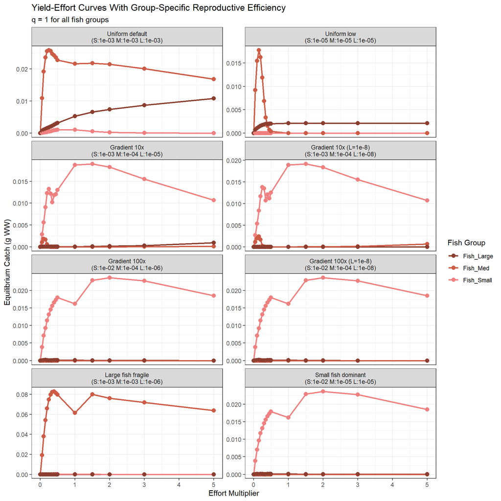

```r
fish_colours <- get_fish_colours(results_group_repro[[1]][[1]])

ggplot(group_repro_summary,
       aes(x = effort, y = eq_catch, colour = fish_group)) +
  geom_line(linewidth = 1.0) +
  geom_point(size = 2.5) +
  facet_wrap(~ scenario_label, scales = "free_y", ncol = 2) +
  scale_colour_manual(values = fish_colours) +
  theme_bw(base_size = 11) +
  labs(x      = "Effort Multiplier",
       y      = "Equilibrium Catch (g WW)",
       colour = "Fish Group",
       title  = "Yield-Effort Curves With Group-Specific Reproductive Efficiency",
       subtitle = paste0("q = ", q_fixed, " for all fish groups"))
```

### 5.2.2 Normalised Yield

Normalised to each group’s own maximum within each scenario.

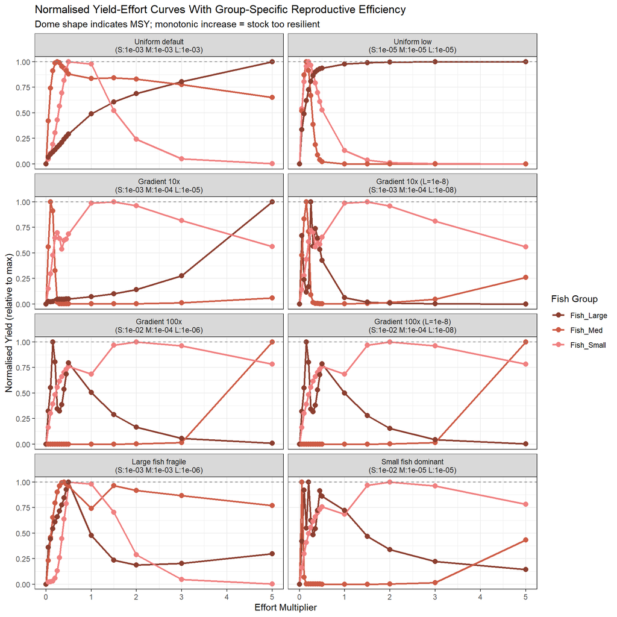

```r
group_repro_summary <- group_repro_summary %>%
  group_by(scenario, fish_group) %>%
  mutate(yield_norm = eq_catch / max(eq_catch, na.rm = TRUE)) %>%
  ungroup()

ggplot(group_repro_summary,
       aes(x = effort, y = yield_norm, colour = fish_group)) +
  geom_line(linewidth = 1.0) +
  geom_point(size = 2.5) +
  geom_hline(yintercept = 1, linetype = "dashed", colour = "grey50") +
  facet_wrap(~ scenario_label, ncol = 2) +
  scale_colour_manual(values = fish_colours) +
  theme_bw(base_size = 11) +
  labs(x      = "Effort Multiplier",
       y      = "Normalised Yield (relative to max)",
       colour = "Fish Group",
       title  = "Normalised Yield-Effort Curves With Group-Specific Reproductive Efficiency",
       subtitle = "Dome shape indicates MSY; monotonic increase = stock too resilient")
```

## 5.3 Biomass Depletion

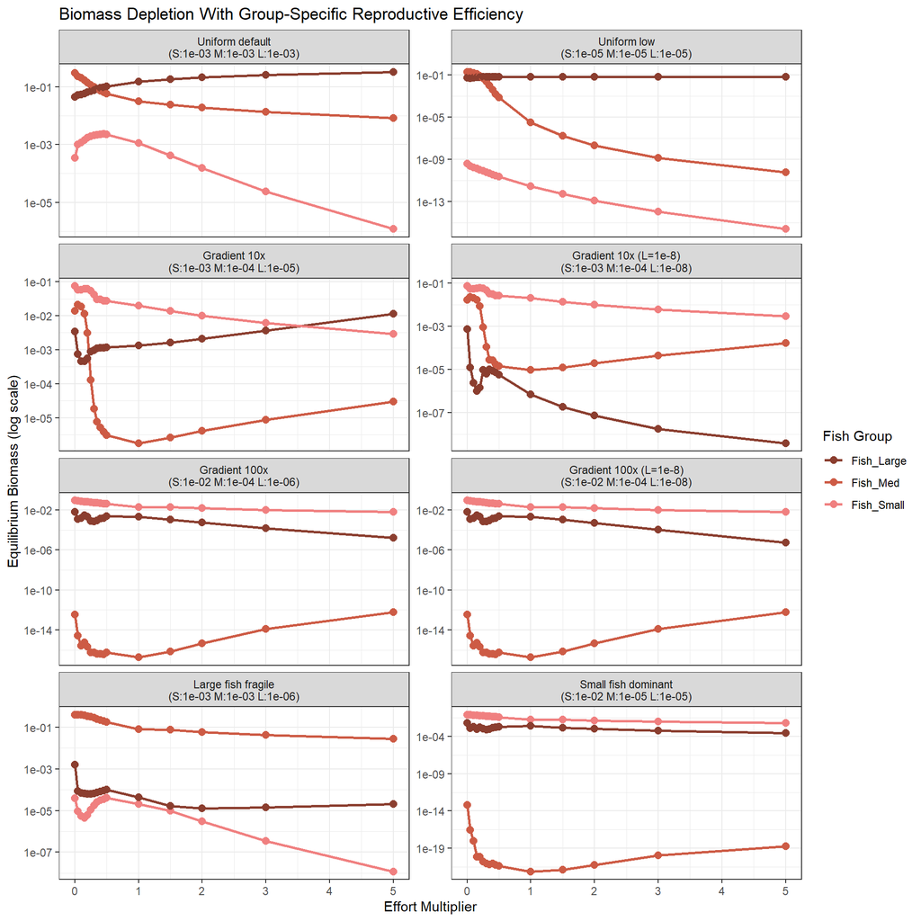

```r
ggplot(group_repro_summary,
       aes(x = effort, y = eq_biomass, colour = fish_group)) +
  geom_line(linewidth = 1.0) +
  geom_point(size = 2.5) +
  facet_wrap(~ scenario_label, scales = "free_y", ncol = 2) +
  scale_colour_manual(values = fish_colours) +
  scale_y_log10() +
  theme_bw(base_size = 11) +
  labs(x      = "Effort Multiplier",
       y      = "Equilibrium Biomass (log scale)",
       colour = "Fish Group",
       title  = "Biomass Depletion With Group-Specific Reproductive Efficiency")
```

## 5.4 SSB and Recruitment

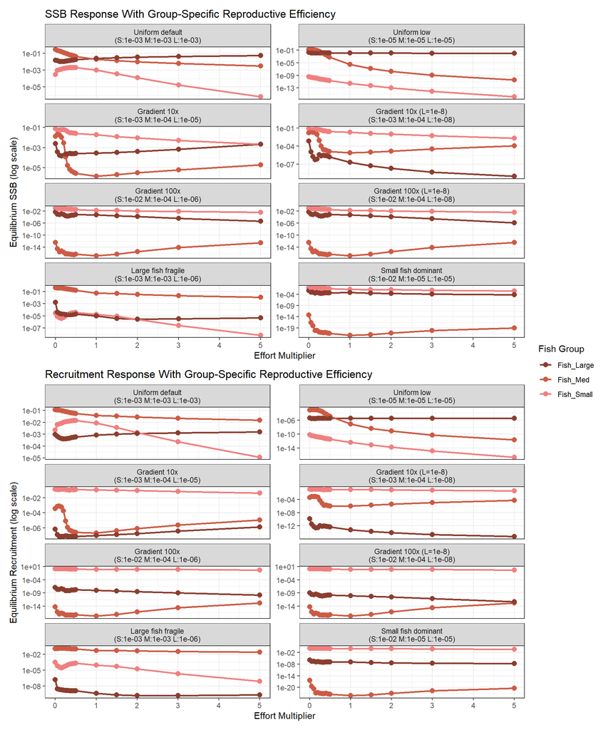

```r
p_ssb_grp <- ggplot(group_repro_summary,
                    aes(x = effort, y = eq_SSB, colour = fish_group)) +
  geom_line(linewidth = 1.0) +
  geom_point(size = 2.5) +
  facet_wrap(~ scenario_label, scales = "free_y", ncol = 2) +
  scale_colour_manual(values = fish_colours) +
  scale_y_log10() +
  theme_bw(base_size = 11) +
  labs(x      = "Effort Multiplier",
       y      = "Equilibrium SSB (log scale)",
       colour = "Fish Group",
       title  = "SSB Response With Group-Specific Reproductive Efficiency")

p_rec_grp <- ggplot(group_repro_summary,
                    aes(x = effort, y = eq_recruitment, colour = fish_group)) +
  geom_line(linewidth = 1.0) +
  geom_point(size = 2.5) +
  facet_wrap(~ scenario_label, scales = "free_y", ncol = 2) +
  scale_colour_manual(values = fish_colours) +
  scale_y_log10() +
  theme_bw(base_size = 11) +
  labs(x      = "Effort Multiplier",
       y      = "Equilibrium Recruitment (log scale)",
       colour = "Fish Group",
       title  = "Recruitment Response With Group-Specific Reproductive Efficiency")

wrap_plots(p_ssb_grp, p_rec_grp, ncol = 1, guides = "collect")
```

## 5.5 Cross-Scenario Comparison

Overlay all scenarios on one panel per fish group to directly compare how different `repro_eff` combinations affect each group’s yield curve.

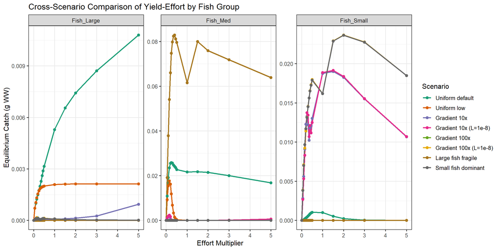

```r
ggplot(group_repro_summary,
       aes(x = effort, y = eq_catch,
           colour = scenario, group = scenario)) +
  geom_line(linewidth = 0.9) +
  geom_point(size = 2) +
  facet_wrap(~ fish_group, scales = "free_y") +
  theme_bw(base_size = 12) +
  scale_colour_brewer(palette = "Dark2") +
  labs(x      = "Effort Multiplier",
       y      = "Equilibrium Catch (g WW)",
       colour = "Scenario",
       title  = "Cross-Scenario Comparison of Yield-Effort by Fish Group")
```

## 5.6 MSY Summary Table

The effort level producing maximum yield for each fish group under each scenario.

```r
msy_table <- group_repro_summary %>%
  group_by(scenario, fish_group) %>%
  summarise(
    MSY            = max(eq_catch, na.rm = TRUE),
    effort_MSY     = effort[which.max(eq_catch)],
    SSB_at_MSY     = eq_SSB[which.max(eq_catch)],
    biomass_at_MSY = eq_biomass[which.max(eq_catch)],
    repro_eff      = unique(repro_eff_fg),
    .groups = "drop"
  ) %>%
  arrange(scenario, fish_group)

knitr::kable(msy_table, digits = 6,
             caption = "MSY summary by scenario and fish group",
             col.names = c("Scenario", "Fish Group", "MSY (g WW)",
                          "Effort at MSY", "SSB at MSY", "Biomass at MSY",
                          "repro_eff"))
```

MSY summary by scenario and fish group

| Scenario | Fish Group | MSY (g WW) | Effort at MSY | SSB at MSY | Biomass at MSY | repro_eff |
| --- | --- | --- | --- | --- | --- | --- |
| Uniform default | Fish_Large | 0.010803 | 5.00 | 0.053262 | 0.325416 | 1e-03 |
| Uniform default | Fish_Med | 0.025864 | 0.25 | 0.098291 | 0.116438 | 1e-03 |
| Uniform default | Fish_Small | 0.001025 | 0.50 | 0.002044 | 0.002237 | 1e-03 |
| Uniform low | Fish_Large | 0.002134 | 5.00 | 0.011559 | 0.064026 | 1e-05 |
| Uniform low | Fish_Med | 0.017750 | 0.15 | 0.118062 | 0.118934 | 1e-05 |
| Uniform low | Fish_Small | 0.000000 | 0.20 | 0.000000 | 0.000000 | 1e-05 |
| Gradient 10x | Fish_Large | 0.000939 | 5.00 | 0.002174 | 0.011568 | 1e-05 |
| Gradient 10x | Fish_Med | 0.001843 | 0.10 | 0.018198 | 0.018845 | 1e-04 |
| Gradient 10x | Fish_Small | 0.018994 | 1.50 | 0.012622 | 0.013669 | 1e-03 |
| Gradient 10x (L=1e-8) | Fish_Large | 0.000001 | 0.25 | 0.000004 | 0.000010 | 0e+00 |
| Gradient 10x (L=1e-8) | Fish_Med | 0.002368 | 0.15 | 0.015533 | 0.016274 | 1e-04 |
| Gradient 10x (L=1e-8) | Fish_Small | 0.019137 | 1.50 | 0.012717 | 0.013766 | 1e-03 |
| Gradient 100x | Fish_Large | 0.000173 | 0.15 | 0.001107 | 0.002791 | 1e-06 |
| Gradient 100x | Fish_Med | 0.000000 | 5.00 | 0.000000 | 0.000000 | 1e-04 |
| Gradient 100x | Fish_Small | 0.023663 | 2.00 | 0.011755 | 0.014710 | 1e-02 |
| Gradient 100x (L=1e-8) | Fish_Large | 0.000174 | 0.15 | 0.001132 | 0.002883 | 0e+00 |
| Gradient 100x (L=1e-8) | Fish_Med | 0.000000 | 5.00 | 0.000000 | 0.000000 | 1e-04 |
| Gradient 100x (L=1e-8) | Fish_Small | 0.023666 | 2.00 | 0.011757 | 0.014712 | 1e-02 |
| Large fish fragile | Fish_Large | 0.000006 | 0.50 | 0.000019 | 0.000101 | 1e-06 |
| Large fish fragile | Fish_Med | 0.082933 | 0.40 | 0.195207 | 0.223327 | 1e-03 |
| Large fish fragile | Fish_Small | 0.000018 | 0.50 | 0.000036 | 0.000040 | 1e-03 |
| Small fish dominant | Fish_Large | 0.000130 | 0.20 | 0.000632 | 0.001644 | 1e-05 |
| Small fish dominant | Fish_Med | 0.000000 | 0.05 | 0.000000 | 0.000000 | 1e-05 |
| Small fish dominant | Fish_Small | 0.023634 | 2.00 | 0.011741 | 0.014695 | 1e-02 |

## 5.7 Depletion Ratio (B/B<sub>0</sub>)

The depletion ratio (`B/B0`, biomass relative to unfished) is a standard fisheries reference metric.

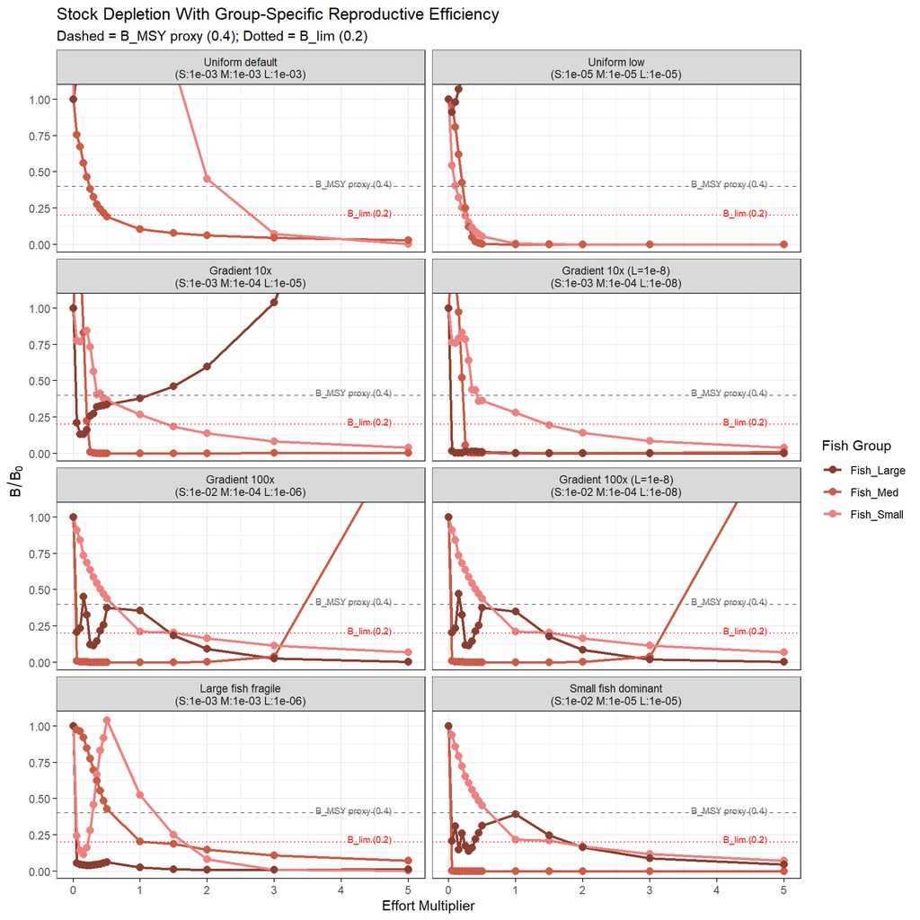

```r
group_repro_summary <- group_repro_summary %>%
  group_by(scenario, fish_group) %>%
  mutate(B0 = eq_biomass[effort == 0],
         depletion = eq_biomass / B0) %>%
  ungroup()

ggplot(group_repro_summary,
       aes(x = effort, y = depletion, colour = fish_group)) +
  geom_line(linewidth = 1.0) +
  geom_point(size = 2.5) +
  geom_hline(yintercept = 0.4, linetype = "dashed",
             colour = "grey50", linewidth = 0.5) +
  geom_hline(yintercept = 0.2, linetype = "dotted",
             colour = "red", linewidth = 0.5) +
  annotate("text", x = max(effort_levels) * 0.95, y = 0.42,
           label = "B_MSY proxy (0.4)", hjust = 1, size = 2.5, colour = "grey40") +
  annotate("text", x = max(effort_levels) * 0.95, y = 0.22,
           label = "B_lim (0.2)", hjust = 1, size = 2.5, colour = "red") +
  facet_wrap(~ scenario_label, ncol = 2) +
  scale_colour_manual(values = fish_colours) +
  coord_cartesian(ylim = c(0, 1.05)) +
  theme_bw(base_size = 11) +
  labs(x      = "Effort Multiplier",
       y      = expression(B / B[0]),
       colour = "Fish Group",
       title  = "Stock Depletion With Group-Specific Reproductive Efficiency",
       subtitle = "Dashed = B_MSY proxy (0.4); Dotted = B_lim (0.2)")
```

## 5.8 Interpretation

Key patterns to look for across scenarios:

1. **Differential vulnerability**: In gradient scenarios, large fish should collapse at lower effort than small fish. If Fish_Large with `repro_eff = 1e-6` shows a dome peak at `effort ~ 0.5` while Fish_Small with `repro_eff = 1e-2` peaks at `effort ~ 3`, this reproduces the empirical pattern of “fishing down the food web” where large species are depleted first.
2. **Trophic feedback**: When large fish collapse, medium and small fish may experience reduced predation mortality and temporarily increase — a mesopredator release. Group-specific `repro_eff` interacts with these trophic dynamics in ways that uniform `repro_eff` cannot capture.
3. **MSY effort separation**: Realistic fisheries management requires different effort levels for different species. If all three groups have MSY at the same effort, the model cannot distinguish selective management strategies.
4. **Depletion thresholds**: The `B/B0` plots with reference lines at 0.4 (BMSY proxy) and 0.2 (Blim) show which scenarios produce realistic stock assessment dynamics.

The scenario that best reproduces these patterns — differential vulnerability, dome-shaped yield curves for all groups, and realistic depletion levels — provides the starting point for calibrating `repro_eff` against observed catch data in the FishMIP framework.